# Practical Machine Learning Project

Ignacio Reboredo

## Overview

This project aims to conduct an analysis over data from accelerometers on the belt, forearm, arm and dumbell of 6 participants while performing barbell lifts, and predict when they performed the exercise correctly and incorrectly in 5 different ways.

## Exploratory Data Analysis

### Data Procesing

```r
## Reading data
test<-read.csv("pml-testing.csv",stringsAsFactors=TRUE)
train<-read.csv("pml-training.csv",stringsAsFactors=TRUE)
str(train[1:36])
```

```
## 'data.frame':    19622 obs. of  36 variables:
##  $ X                   : int  1 2 3 4 5 6 7 8 9 10 ...
##  $ user_name           : Factor w/ 6 levels "adelmo","carlitos",..: 2 2 2 2 2 2 2 2 2 2 ...
##  $ raw_timestamp_part_1: int  1323084231 1323084231 1323084231 1323084232 1323084232 1323084232 1323084232 1323084232 1323084232 1323084232 ...
##  $ raw_timestamp_part_2: int  788290 808298 820366 120339 196328 304277 368296 440390 484323 484434 ...
##  $ cvtd_timestamp      : Factor w/ 20 levels "02/12/2011 13:32",..: 9 9 9 9 9 9 9 9 9 9 ...
##  $ new_window          : Factor w/ 2 levels "no","yes": 1 1 1 1 1 1 1 1 1 1 ...
##  $ num_window          : int  11 11 11 12 12 12 12 12 12 12 ...
##  $ roll_belt           : num  1.41 1.41 1.42 1.48 1.48 1.45 1.42 1.42 1.43 1.45 ...
##  $ pitch_belt          : num  8.07 8.07 8.07 8.05 8.07 8.06 8.09 8.13 8.16 8.17 ...
##  $ yaw_belt            : num  -94.4 -94.4 -94.4 -94.4 -94.4 -94.4 -94.4 -94.4 -94.4 -94.4 ...
##  $ total_accel_belt    : int  3 3 3 3 3 3 3 3 3 3 ...
##  $ kurtosis_roll_belt  : Factor w/ 397 levels "","-0.016850",..: 1 1 1 1 1 1 1 1 1 1 ...
##  $ kurtosis_picth_belt : Factor w/ 317 levels "","-0.021887",..: 1 1 1 1 1 1 1 1 1 1 ...
##  $ kurtosis_yaw_belt   : Factor w/ 2 levels "","#DIV/0!": 1 1 1 1 1 1 1 1 1 1 ...
```

[output cut: 22 more lines]

A first exploratory analysis allows to identify many variables where most of the values are NAs. That the variables correspond to summaries by time window as they occur only when the window change

The first thougth was try to use only summary variables to build the model, but some of them seem to have been swapped so due to these discrepancies I dicided not to use this variables as predictors

In addition, variables with zero or near zero variance were removed as well as the first columns that didn’t provide relevant information as predictors and could introduce overfitting in training

```r
## creationg training and testing sets

inTrain<-createDataPartition(y=train$classe,p=0.7,list=FALSE)
Training0<-train
Training<-train[inTrain,]
Testing<-train[-inTrain,]

## removing predictors with NAs in test and training sets

Training<-Training[,colSums(is.na(test))==0]

## removing predictors with zero or near zero variance

ZeroVar<-nearZeroVar(Training,saveMetrics=TRUE)
Training<-Training[,(ZeroVar$nzv==FALSE)&(ZeroVar$nzv==FALSE)]

## removing the first columns corresponding with variables that don't work as predictors and can induce overfitting X (numer of sample), time stamp vars and num window

Training<-Training[,7:dim(Training)[2]]
```

As result of the the exploratory data analysis, predictors were reduced from 160 to 53

## Machine Learning Algorithm

Due to the key objective is to obtain a good predictor and not interpret the results, I decided to use Random Forest algorithm that allows to reach high accuracy and don’t require data standardization like in regresion models

### Random Forest with 53 predictors

```r
### Random Forest model with 53 predictors

set.seed(4321)
train_rf<-randomForest(classe~.,data = Training,importance=TRUE)

pred<-predict(train_rf,Testing)
cm<-confusionMatrix(pred,Testing$classe)
cm
```

The Random Forest algorithm over the 53 predictors provides a high accuracy as shown bellow:

```
## Confusion Matrix and Statistics
##
##           Reference
## Prediction    A    B    C    D    E
##          A 1674    0    0    0    0
##          B    0 1136   11    0    0
##          C    0    3 1015   16    0
##          D    0    0    0  948    2
##          E    0    0    0    0 1080
##
## Overall Statistics
##
##                Accuracy : 0.9946
##                  95% CI : (0.9923, 0.9963)
##     No Information Rate : 0.2845
##     P-Value [Acc > NIR] : < 2.2e-16
##
##                   Kappa : 0.9931
##  Mcnemar's Test P-Value : NA
##
## Statistics by Class:
##
##                      Class: A Class: B Class: C Class: D Class: E
## Sensitivity            1.0000   0.9974   0.9893   0.9834   0.9982
## Specificity            1.0000   0.9977   0.9961   0.9996   1.0000
## Pos Pred Value         1.0000   0.9904   0.9816   0.9979   1.0000
## Neg Pred Value         1.0000   0.9994   0.9977   0.9968   0.9996
## Prevalence             0.2845   0.1935   0.1743   0.1638   0.1839
## Detection Rate         0.2845   0.1930   0.1725   0.1611   0.1835
## Detection Prevalence   0.2845   0.1949   0.1757   0.1614   0.1835
## Balanced Accuracy      1.0000   0.9975   0.9927   0.9915   0.9991
```

## Cross Validations and Out of Sample Error

But high accuracy, mainly when many predictors are used building the learning algorith, can be synonym of overfitting. For this reason, we will tray to reduce the number of preditors while minimizing the impact in accuracy

The first step is identify those variables that better performe as predictors

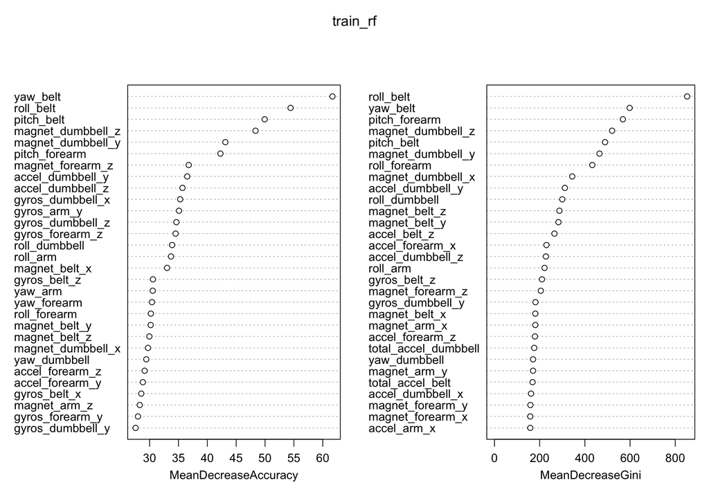

Where most accurate predictors are yaw_belt, roll_belt, pitch_belt, magnet_dumbbell_z, magnet_dumbbell_y and pitch_forearm

### Random Forest with 2 predictors

Building the model for the two most accurate predictors “yaw_belt” and “roll_belt”:

```r
## Random Forest with two main predictors

Training_2<-subset(Training,select=c("yaw_belt","roll_belt","classe"))
set.seed(1234)

train_rf_2<-randomForest(classe~.,data = Training_2,importance=TRUE)
pred_2<-predict(train_rf_2,Testing)
cm_2<-confusionMatrix(pred_2,Testing$classe)
cm_2
```

The Random Forest algorithm over these two predictors provides the following results:

```
## Confusion Matrix and Statistics
##
##           Reference
## Prediction    A    B    C    D    E
##          A 1340  169  196   95   74
##          B   72  790  142   38   26
##          C  116   94  500   46   20
##          D  136   58  177  744   45
##          E   10   28   11   41  917
##
## Overall Statistics
##
##                Accuracy : 0.7291
##                  95% CI : (0.7176, 0.7405)
##     No Information Rate : 0.2845
##     P-Value [Acc > NIR] : < 2.2e-16
##
##                   Kappa : 0.6561
##  Mcnemar's Test P-Value : < 2.2e-16
##
## Statistics by Class:
##
##                      Class: A Class: B Class: C Class: D Class: E
## Sensitivity            0.8005   0.6936  0.48733   0.7718   0.8475
## Specificity            0.8732   0.9414  0.94320   0.9155   0.9813
## Pos Pred Value         0.7150   0.7397  0.64433   0.6414   0.9106
## Neg Pred Value         0.9167   0.9275  0.89704   0.9534   0.9662
## Prevalence             0.2845   0.1935  0.17434   0.1638   0.1839
## Detection Rate         0.2277   0.1342  0.08496   0.1264   0.1558
## Detection Prevalence   0.3184   0.1815  0.13186   0.1971   0.1711
## Balanced Accuracy      0.8368   0.8175  0.71526   0.8436   0.9144
```

As can be show, this model has a low accuracy, which leads him to commit many misclassification. As conclusion, the two main predictors are not enought to build a good predictor model, so we need to add aditional predictors to our model

### Random Forest with 6 predictors

Building the prediction model with the six most accurate predictors “yaw_belt”, “roll_belt”, “pitch_belt”, “magnet_dumbbell_z”, “magnet_dumbbell_y” and “pitch_forearm”:

```r
## Random Forest with six main predictors

Training_6<-subset(Training,select=c("yaw_belt","roll_belt","pitch_belt","magnet_dumbbell_z","magnet_dumbbell_y","pitch_forearm","classe"))
set.seed(1234)

train_rf_6<-randomForest(classe~.,data = Training_6,importance=TRUE)
pred_6<-predict(train_rf_6,Testing)
cm_6<-confusionMatrix(pred_6,Testing$classe)
cm_6
```

The Random Forest algorithm over these six predictors provides the following results:

```
## Confusion Matrix and Statistics
##
##           Reference
## Prediction    A    B    C    D    E
##          A 1656    6    2    1    3
##          B    8 1110   10    1   12
##          C    5   17 1003    7    0
##          D    4    5   11  953    2
##          E    1    1    0    2 1065
##
## Overall Statistics
##
##                Accuracy : 0.9833
##                  95% CI : (0.9797, 0.9865)
##     No Information Rate : 0.2845
##     P-Value [Acc > NIR] : < 2.2e-16
##
##                   Kappa : 0.9789
##  Mcnemar's Test P-Value : NA
##
## Statistics by Class:
##
##                      Class: A Class: B Class: C Class: D Class: E
## Sensitivity            0.9892   0.9745   0.9776   0.9886   0.9843
## Specificity            0.9972   0.9935   0.9940   0.9955   0.9992
## Pos Pred Value         0.9928   0.9728   0.9719   0.9774   0.9963
## Neg Pred Value         0.9957   0.9939   0.9953   0.9978   0.9965
## Prevalence             0.2845   0.1935   0.1743   0.1638   0.1839
## Detection Rate         0.2814   0.1886   0.1704   0.1619   0.1810
## Detection Prevalence   0.2834   0.1939   0.1754   0.1657   0.1816
## Balanced Accuracy      0.9932   0.9840   0.9858   0.9921   0.9917
```

We can see how the new model provide us a high accuracy (98,33%, not far from the 99,46% reached with 53 predictors) with only 6 predictors, so I will finally use this model to make the test predictions

### Test prediction

```r
## Prediction over test set

pred_test<-predict(train_rf_6,test)
```